# Actividad 4

- Procedure
  - Dependencies
- Analysis 1
  - Before alignment
  - Results of sequence alignment (showing only first 233)
  - After alignment
  - Alignment of the first 1,000 bases
  - Complete alignment
  - Difference matrix (between sequences)
- Using `ggplot2`
- Analysis 2: Different variants of coronavirus
  - Before alignment
  - Results of sequence alignment (showing only first 360)
  - After alignment
  - Alignment of the first 1,000 bases
  - Complete alignment
  - Difference matrix (between sequences)
- Using `ggplot2`
- Key learnings
- References

Análisis de biología computacional `BT1013.525`

```
Bryan Manuel De la O Perea  A01246337
Andrés Sarellano Acevedo    A01245418
Maximiliano Villegas García A01635825
Víctor Manuel Puga Ruiz     A01568636
```

# Procedure

These are the steps we followed in order to identify the phylogenetic tree of these variants of the SARS-CoV-2 virus:

- Collected all the sequences (5 variants + the reference genome).
- Merged all the `.fastas` in a single file.
- Used the Clustal Omega tool (https://www.ebi.ac.uk/Tools/msa/clustalo/) to align the sequences.

> Our results can be found in https://www.ebi.ac.uk/Tools/services/web/toolresult.ebi?jobId=clustalo-I20210425-021750-0190-3504822-p2m and https://www.ebi.ac.uk/Tools/services/web/toolresult.ebi?jobId=clustalo-I20210423-005428-0562-5987948-p1m (will only be available for a limited time).
- Used the aligned sequences to calculate the “Pairwise Distances from DNA Sequences”.
- Used these results to build the tree with “Neighbor-Joining Tree Estimation”.
- **NOTE:** We repeated the process with the sequences provided by the activity, and another analysis for the sequences we gathered in the previous activity.

## Dependencies

```r
suppressMessages(library(seqinr))
suppressMessages(library(Biostrings))
suppressMessages(library(ape))
suppressMessages(library(ggplot2))
suppressMessages(library(ggtree))
```

# Analysis 1

```r
accessions <- c(
  "JX869059", "AY508724", "MN908947", "AY390556",
  "AY278489", "MN985325", "AY485277", "MT292571"
)

read.file <- function(loc) {
  my_data <- readChar(loc, file.info(loc)$size)
  cat(my_data)
}

plot.colors = c(
    "-" = "#000000",
    "a" = "#106BFF",
    "t" = "#FC2B2D",
    "g" = "#30D33B",
    "c" = "#FECF0F",
    "n" = "#FD8D0E"
)
```

## Before alignment

```r
all.seq = read.dna("./virus/MERGED.fasta", format = "fasta")
all.seq
```

```
## 8 DNA sequences in binary format stored in a list.
##
## Mean sequence length: 29834.5
##    Shortest sequence: 29732
##     Longest sequence: 30119
##
## Labels:
## AY278489.2 SARS coronavirus GD01, complete genome
## AY390556.1 SARS coronavirus GZ02, complete genome
## AY485277.1 SARS coronavirus Sino1-11, complete genome
## AY508724.1 SARS coronavirus NS-1, complete genome
## JX869059.2 Human betacoronavirus 2c EMC/2012, complete genom...
## MN908947.3 Severe acute respiratory syndrome coronavirus 2 i...
## ...
##
## Base composition:
##     a     c     g     t
## 0.287 0.194 0.204 0.315
## (Total: 238.68 kb)
```

## Results of sequence alignment (showing only first 233)

```r
read.file("./virus/aligned-first-places.txt")
```

```
## CLUSTAL O(1.2.4) multiple sequence alignment
##
##
## JX869059.2      -------GATTTAAGTGAATAGCTTGGCTATCTCACTTCCCCTCGTTCTCTTGCAGAACT 53
## MT292571.1      ------------------------------------------------------AGATCT 6
## MN908947.3      ATTAAAGGTTTATACCTTCCCAGGTAACAAACCAACCAACTTTCGATCTCTTGTAGATCT 60
## MN985325.1      ATTAAAGGTTTATACCTTCCCAGGTAACAAACCAACCAACTTTCGATCTCTTGTAGATCT 60
## AY485277.1      ATATTAGGTTTTTACCTACCCAGG--AAAAGCCAACCAAC-CTCGATCTCTTGTAGATCT 57
## AY508724.1      ----------------TACCCAGG--AAAAGCCAACCAAC-CTCGATCTCTTGTAGATCT 41
## AY278489.2      ----------------TACCCAGG--AAAAGCCAACCAAC-CTCGATCTCTTGTAGATCT 41
## AY390556.1      ATATTAGGTTTTTACCTACCCAGG--AAAAGCCAACCAAC-CTCGATCTCTTGTAGATCT 57
##                                                                       *** **
##
## JX869059.2      TTGATTTTAACGAACTTAAATAAAAGCCCTGTTGTTTAGCGTATCGTTGCACTTGTCTGG 113
## MT292571.1      GTTCTCTAAACGAACTTTAAAATCTGTGTGGCTGT------------------------- 41
## MN908947.3      GTTCTCTAAACGAACTTTAAAATCTGTGTGGCTGT------------------------- 95
## MN985325.1      GTTCTCTAAACGAACTTTAAAATCTGTGTGGCTGT------------------------- 95
## AY485277.1      GTTCTCTAAACGAACTTTAAAATCTGTGTAGCTGT------------------------- 92
## AY508724.1      GTTCTCTAAACGAACTTTAAAATCTGTGTAGCTGT------------------------- 76
## AY278489.2      GTTCTCTAAACGAACTTTAAAATCTGTGTAGCTGT------------------------- 76
## AY390556.1      GTTCTCTAAACGAACTTTAAAATCTGTGTAGCTGT------------------------- 92
##                  *  * * ********* ** *   *    * ***
##
## JX869059.2      TGGGATTGTGGCATTAATTTGCCTGCTCATCTAGGCAGTGGACATATGCTCAACACTGGG 173
## MT292571.1      ----------------------------CACTCGGCTGCATGCTTAGTGCACTCACGCAG 73
## MN908947.3      ----------------------------CACTCGGCTGCATGCTTAGTGCACTCACGCAG 127
## MN985325.1      ----------------------------CACTCGGCTGCATGCTTAGTGCACTCACGCAG 127
## AY485277.1      ----------------------------CGCTCGGCTGCATGCCTAGTGCACCTACGCAG 124
## AY508724.1      ----------------------------CGCTCGGCTGCATGCCTAGTGCACCTACGCAG 108
## AY278489.2      ----------------------------CGCTCGGCTGCATGCCTAGTGCACCTACGCAG 108
## AY390556.1      ----------------------------CGCTCGGCTGCATGCCTAGTGCACCTACGCAG 124
##                                               ** *** *    * **        **   *
##
## JX869059.2      TATAATTCTAATTGAATACTATTTTTCAGTTAGAGCGTCGTGTCTCTTGTACGTCTCGGT 233
## MT292571.1      TATAATTAATAACTAA--TTACTGTCGTTGACAGGACACGAGTAACTCGTCTATCTTCTG 131
## MN908947.3      TATAATTAATAACTAA--TTACTGTCGTTGACAGGACACGAGTAACTCGTCTATCTTCTG 185
## MN985325.1      TATAATTAATAACTAA--TTACTGTCGTTGACAGGACACGAGTAACTCGTCTATCTTCTG 185
## AY485277.1      TATAAACAATAATAAATTTTACTGTCGTTGACAAGAAACGAGTAACTCGTCCCTCTTCTG 184
## AY508724.1      TATAAACAATAATAAATTTTACTGTCGTTGACAAGAAACGAGTAACTCGTCCCTCTTCTG 168
## AY278489.2      TATAAACAATAATAAATTTTACTGTCGTTGACAAGAAACGAGTAACTCGTCCCTCTTCTG 168
## AY390556.1      TATAAACAATAATAAATTTTACTGTCGTTGACAAGAAACGAGTAACTCGTCCCTCTTCTG 184
##                 *****     *   **   ** * *         *   ** **  ** **   ***
```

## After alignment

```r
clust <- read.alignment(
  "./virus/clustalo-I20210425-021750-0190-3504822-p2m.clustal_num",
  format = "clustal", forceToLower = TRUE,
)
dna <- as.DNAbin(clust)
dna
```

```
## 8 DNA sequences in binary format stored in a matrix.
##
## All sequences of same length: 33165
##
## Labels:
## JX869059.2
## MT292571.1
## MN908947.3
## MN985325.1
## AY485277.1
## AY508724.1
## ...
##
## Base composition:
##     a     c     g     t
## 0.287 0.194 0.204 0.315
## (Total: 265.32 kb)
```

## Alignment of the first 1,000 bases

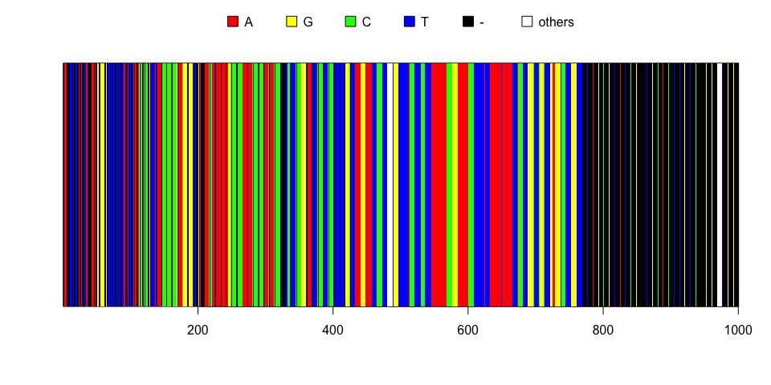

```r
image.DNAbin(dna[1:1000])
```

## Complete alignment

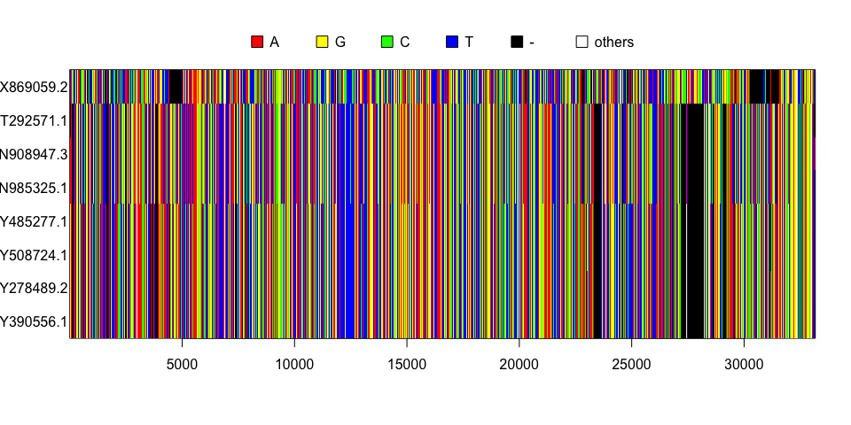

```r
image.DNAbin(dna)
```

## Difference matrix (between sequences)

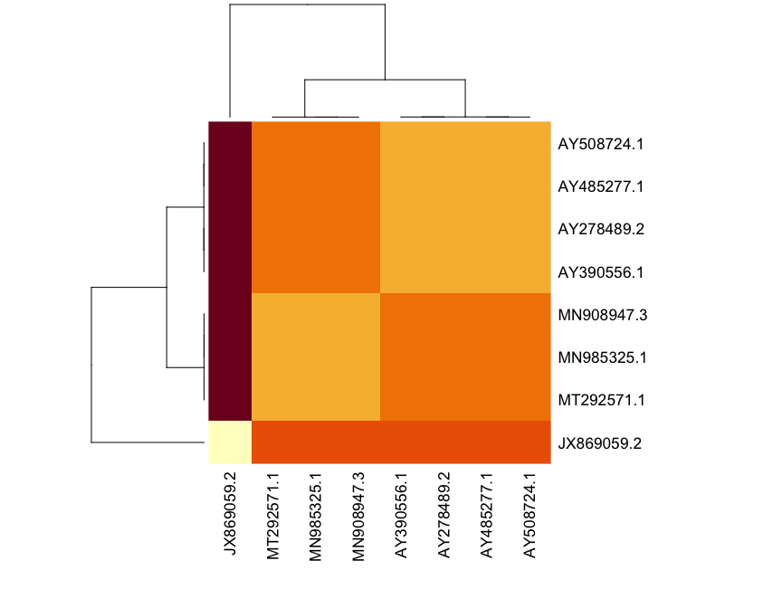

```r
D <- dist.dna(dna)
D.mat <- as.matrix(D)

heatmap(D.mat, margins = c(10, 10))
```

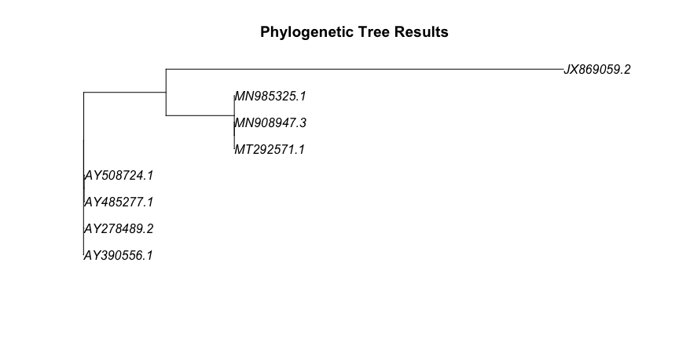

```r
tree <- nj(D)
plot.phylo(tree, main = "Phylogenetic Tree Results")
```

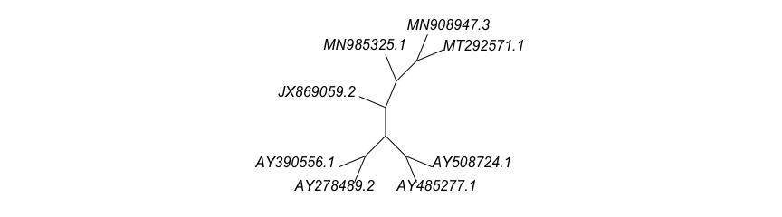

```r
plot.phylo(
  unroot(tree),
  type = "unrooted",
  no.margin = TRUE,
  use.edge.length = FALSE ## not to scale in order to avoid overlaps
)
```

# Using `ggplot2`

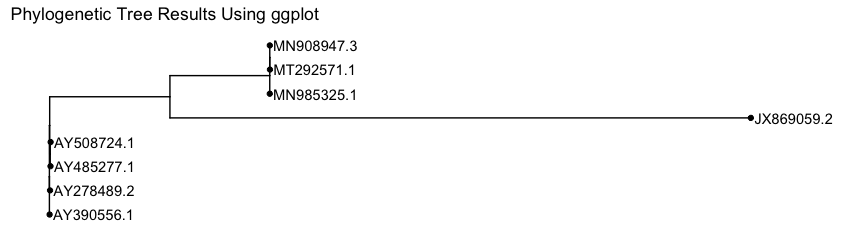

```r
ggtree(tree) + ggtitle("Phylogenetic Tree Results Using ggplot") +
  geom_tippoint() + geom_tiplab() + xlim(0, 0.8)
```

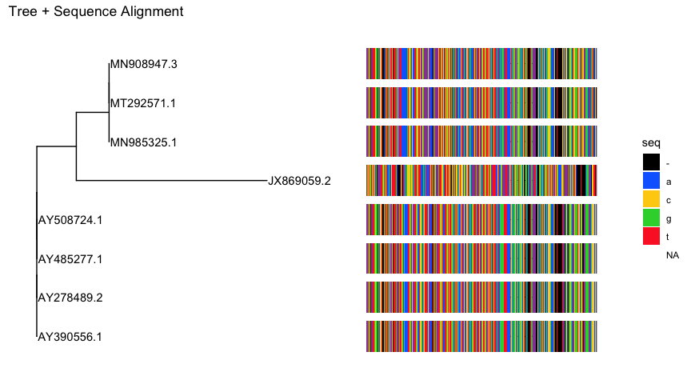

```r
msaplot(p=ggtree(tree), fasta = dna, color=plot.colors, offset=0.3) +
  ggtitle("Tree + Sequence Alignment") +
  geom_tiplab()
```

# Analysis 2: Different variants of coronavirus

```r
accessions <- c(
  "MN908947.3" = "Reference genome",
  "MW913791.1" = "B.1.1.7",
  "FR990267.1" = "B.1.351",
  "FR990291.1" = "P.1",
  "MW453109.1" = "B.1.427",
  "MW778462.1" = "B.1.429"
)
```

## Before alignment

```r
all.seq = read.dna(
  "../SARS-CoV-2 Sequences (Sample)/SARS-CoV-2 MERGED.fasta", format = "fasta"
)
all.seq
```

```
## 6 DNA sequences in binary format stored in a list.
##
## Mean sequence length: 29833.33
##    Shortest sequence: 29692
##     Longest sequence: 29903
##
## Labels:
## MN908947.3 Severe acute respiratory syndrome coronavirus 2 i...
## MW913791.1 Severe acute respiratory syndrome coronavirus 2 i...
## FR990267.1 Severe acute respiratory syndrome coronavirus 2 i...
## FR990291.1 Severe acute respiratory syndrome coronavirus 2 i...
## MW453109.1 Severe acute respiratory syndrome coronavirus 2 i...
## MW778462.1 Severe acute respiratory syndrome coronavirus 2 i...
##
## Base composition:
##     a     c     g     t
## 0.299 0.184 0.196 0.322
## (Total: 179 kb)
```

## Results of sequence alignment (showing only first 360)

```r
read.file("../SARS-CoV-2 Sequences (Sample)/aligned-first-360-places.txt")
```

```
## CLUSTAL O(1.2.4) multiple sequence alignment
##
## MW913791.1      ------------------------------------------------------AGATCT 6
## FR990267.1      --------------------------------------actttcgatctcttgtagatct 22
## MW453109.1      -----------------------------------CCAACTTTCGATCTCTTGTAGATCT 25
## FR990291.1      attaaaggtttataccttcccaggtaacaaaccaaccaactttcgatctcttgtagatct 60
## MN908947.3      ATTAAAGGTTTATACCTTCCCAGGTAACAAACCAACCAACTTTCGATCTCTTGTAGATCT 60
## MW778462.1      --------TTTATACCTTCCCAGGTAACAAACCAACCAACTTTCGATCTCTTGTAGATCT 52
##                                                                       ******
##
## MW913791.1      GTTCTCTAAACGAACTTTAAAATCTGTGTGGCTGTCACTCGGCTGCATGCTTAGTGCACT 66
## FR990267.1      gttctctaaacgaactttaaaatctgtgtggctgtcactcggctgcatgcttagtgcact 82
## MW453109.1      GTTCTCTAAACGAACTTTAAAATCTGTGTGGCTGTCACTCGGCTGCATGCTTAGTGCACT 85
## FR990291.1      gttctctaaacgaactttaaaatctgtgtggctgtcactcggctgcatgcttagtgcact 120
## MN908947.3      GTTCTCTAAACGAACTTTAAAATCTGTGTGGCTGTCACTCGGCTGCATGCTTAGTGCACT 120
## MW778462.1      GTTCTCTAAACGAACTTTAAAATCTGTGTGGCTGTCACTCGGCTGCATGCTTAGTGCACT 112
##
## MW913791.1      CACGCAGTATAATTAATAACTAATTACTGTCGTTGACAGGACACGAGTAACTCGTCTATC 126
## FR990267.1      cacgcagtataattaataactaattactgtcgttgacaggacacgagtaactcttctatc 142
## MW453109.1      CACGCAGTATAATTAATAACTAATTACTGTCGTTGACAGGACACGAGTAACTCGTCTATC 145
## FR990291.1      cacgcagtataattaataactaattactgtcgttgacaggacacgagtaactcgtctatc 180
## MN908947.3      CACGCAGTATAATTAATAACTAATTACTGTCGTTGACAGGACACGAGTAACTCGTCTATC 180
## MW778462.1      CACGCAGTATAATTAATAACTAATTACTGTCGTTGACAGGACACGAGTAACTCGTCTATC 172
##                 ***************************************************** ******
##
## MW913791.1      TTCTGCAGGCTGCTTACGGTTTCGTCCGTGTTGCAGCCGATCATCAGCACATCTAGGTTT 186
## FR990267.1      ttctgcaggctgcttacggtttcgtccgtgttgcagccgatcatcagcacatctaggttt 202
## MW453109.1      TTCTGCAGGCTGCTTACGGTTTCGTCCGTGTTGCAGCCGATCATCAGCACATCTAGGTTT 205
## FR990291.1      ttctgcaggctgcttacggtttcgtccgtgttgcagccgatcatcagcacatctaggttt 240
## MN908947.3      TTCTGCAGGCTGCTTACGGTTTCGTCCGTGTTGCAGCCGATCATCAGCACATCTAGGTTT 240
## MW778462.1      TTCTGCAGGCTGCTTACGGTTTCGTCCGTGTTGCAGCCGATCATCAGCACATCTAGGTTT 232
##
## MW913791.1      TGTCCGGGTGTGACCGAAAGGTAAGATGGAGAGCCTTGTCCCTGGTTTCAACGAGAAAAC 246
## FR990267.1      tgtccgggtgtgaccgaaaggtaagatggagagccttgtccctggtttcaacgagaaaac 262
## MW453109.1      TGTCCGGGTGTGACCGAAAGGTAAGATGGAGAGCCTTGTCCCTGGTTTCAACGAGAAAAC 265
## FR990291.1      tgtccgggtgtgaccgaaaggtaagatggagagccttgtccctggtttcaacgagaaaac 300
## MN908947.3      CGTCCGGGTGTGACCGAAAGGTAAGATGGAGAGCCTTGTCCCTGGTTTCAACGAGAAAAC 300
## MW778462.1      TGTCCGGGTGTGACCGAAAGGTAAGATGGAGAGCCTTGTCCCTGGTTTCAACGAGAAAAC 292
##
## MW913791.1      ACACGTCCAACTCAGTTTGCCTGTTTTACAGGTTCGCGACGTGCTCGTACGTGGCTTTGG 306
## FR990267.1      acacgtccaactcagtttgcctgttttacaggttcgcgacgtgctcgtacgtggctttgg 322
## MW453109.1      ACACGTCCAACTCAGTTTGCCTGTTTTACAGGTTCGCGACGTGCTCGTACGTGGCTTTGG 325
## FR990291.1      acacgtccaactcagtttgcctgttttacaggttcgcgacgtgctcgtacgtggctttgg 360
## MN908947.3      ACACGTCCAACTCAGTTTGCCTGTTTTACAGGTTCGCGACGTGCTCGTACGTGGCTTTGG 360
## MW778462.1      ACACGTCCAACTCAGTTTGCCTGTTTTACAGGTTCGCGACGTGCTCGTACGTGGCTTTGG 352
```

## After alignment

```r
clust <- read.alignment(
  "../SARS-CoV-2 Sequences (Sample)/clustalo-I20210423-005428-0562-5987948-p1m.clustal_num",
  format = "clustal", forceToLower = TRUE,
)
dna <- as.DNAbin(clust)
dna
```

```
## 6 DNA sequences in binary format stored in a matrix.
##
## All sequences of same length: 30406
##
## Labels:
## MW913791.1
## FR990267.1
## MW453109.1
## FR990291.1
## MN908947.3
## MW778462.1
##
## Base composition:
##     a     c     g     t
## 0.299 0.184 0.196 0.322
## (Total: 182.44 kb)
```

## Alignment of the first 1,000 bases

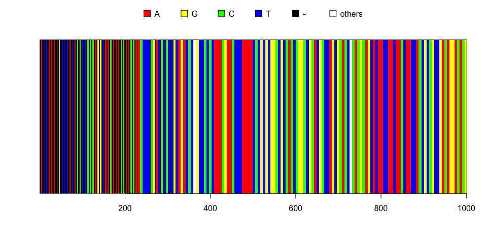

```r
image.DNAbin(dna[1:1000])
```

## Complete alignment

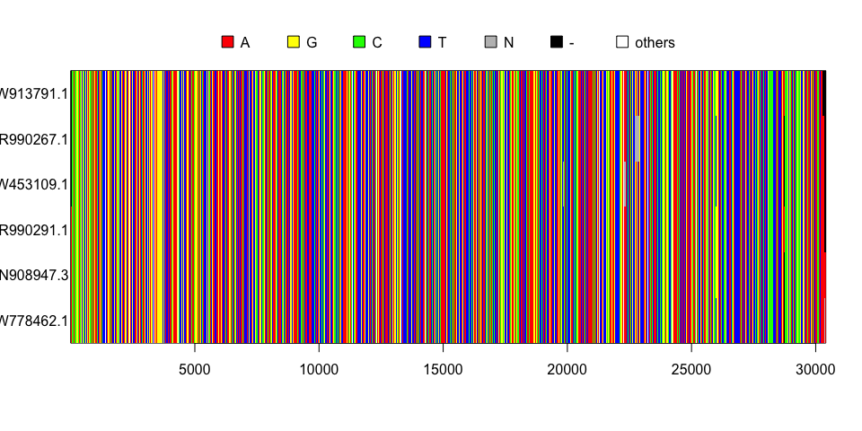

```r
image.DNAbin(dna)
```

## Difference matrix (between sequences)

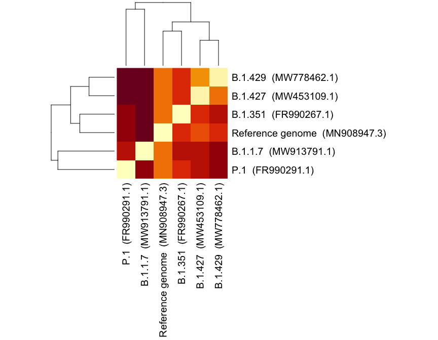

```r
D <- dist.dna(dna, model = "TN93")
D.mat <- as.matrix(D)

rows <- sapply(row.names(D.mat), function(i) { paste(accessions[[i]], "  (", i, ")", sep = "") })
cols <- sapply(colnames(D.mat),  function(i) { paste(accessions[[i]], "  (", i, ")", sep = "") })

heatmap(D.mat, margins = c(20, 20), labRow = rows, labCol = cols)
```

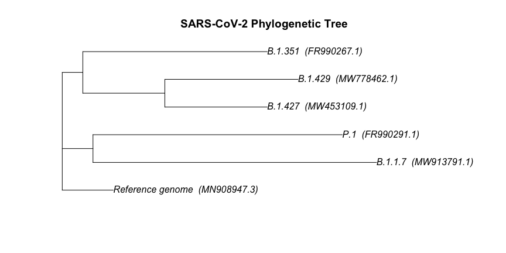

```r
tree <- nj(D)
labs <- sapply(tree$tip.label, function(i) { paste(accessions[[i]], "  (", i, ")", sep = "") })
tree$tip.label <- labs;

plot.phylo(tree, main = "SARS-CoV-2 Phylogenetic Tree")
```

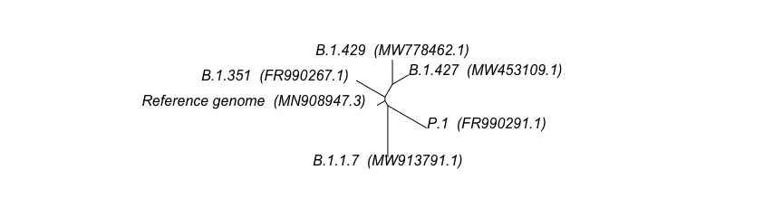

```r
plot.phylo(unroot(tree), type = "unrooted", no.margin = TRUE)
```

# Using `ggplot2`

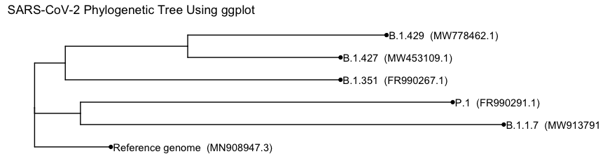

```r
ggtree(tree) + ggtitle("SARS-CoV-2 Phylogenetic Tree Using ggplot") +
  geom_tippoint() + geom_tiplab() + xlim(0, 0.0012)
```

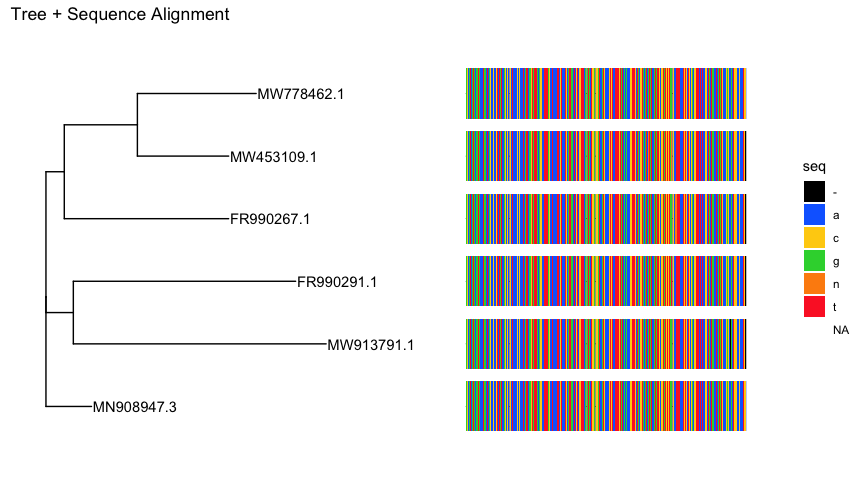

```r
tree$tip.label <- names(tree$tip.label)
msaplot(p=ggtree(tree), fasta = dna, color=plot.colors, offset = 0.0005) +
  ggtitle("Tree + Sequence Alignment") +
  geom_tiplab()
```

# Key learnings

- In the first analysis, some samples of SARS-CoV-2 resemble each other a lot. They were probably from an outbreak in the same region in similar times.
  - This is illustrated by the branches in the tree from the same node that have similar lengths.
- In the second analysis, it is shown how the different classified variants of the virus are related to each other:
  - The Reference Genome from Wu Han is *most likely* their ancestor.
  - The other variants are *newer*, as they are farther in the tree.
  - Our research had previously stated that the `B.1.427` and `B.1.429` variants were closely related.

# References

- *Module 24: An Intro to Phylogenetic Tree Construction in R*. Retrieved on April 22, 2021, from https://fuzzyatelin.github.io/bioanth-stats/module-24/module-24.html
- *Pairwise Distances from DNA Sequences*. Retrieved on April 22, 2021, from https://www.rdocumentation.org/packages/ape/versions/5.4-1/topics/dist.dna
- *Tajimas D for sequences of different length*. Retrieved on April 22, 2021, from https://stackoverflow.com/questions/33301632/tajimas-d-for-sequences-of-different-length
- *Visualizing and Annotating Phylogenetic Trees with R+ggtree*. Retrieved on April 23, 2021, from https://4va.github.io/biodatasci/r-ggtree.html